# Practical 1

Kevin Patyk

11/18/2021

# Introduction

In this practical, we will deal with the curse of dimensionality by applying the “bet on sparsity”. We will use the following packages in the process:

```r
library(tidyverse)
library(glmnet)
```

# Gene expression data

The data file we will be working with is gene expression data. Using microarrays, the expression of many genes can be measured at the same time. The data file contains expressions for 54675 genes with IDs such as 1007_s_at, 202896_s_at, AFFX-r2-P1-cre-3_at. (NB: these IDs are specific for this type of chip and need to be converted to actual gene names before they can be looked up in a database such as “GeneCards”). The values in the data file are related to the amount of RNA belonging to each gene found in the tissue sample.

The goal of the study for which this data was collected is one of exploratory cancer classification: are there differences in gene expression between tissue samples of human prostates with and without prostate cancer?

**1: Read the data file gene_expressions.rds using read_rds(). What are the dimensions of the data? What is the sample size?**

```r
gene <- read_rds("gene_expression.rds")

dim(gene)
```

```
## [1]   237 54676
```

The sample size of the data is 237 and there are 54,676 variables.

**2: As always, visualisation is a good idea. Create histograms of the first 6 variables. Describe what you notice.**

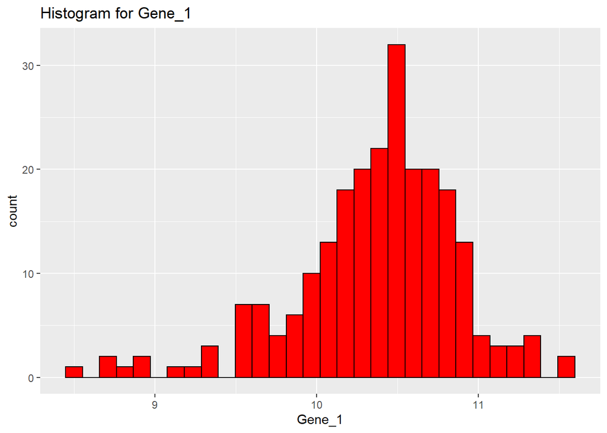

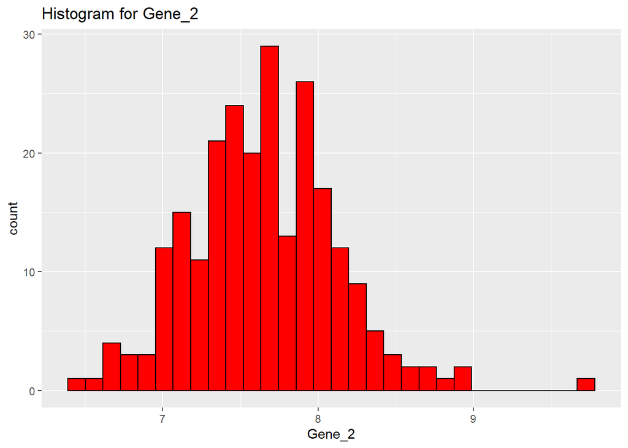

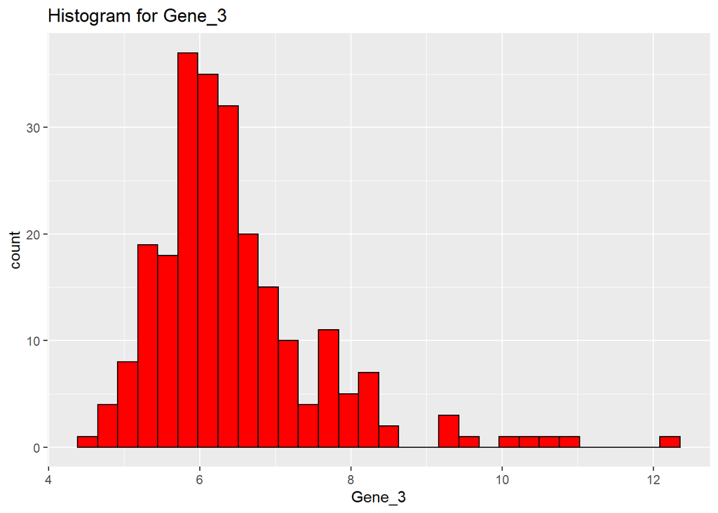

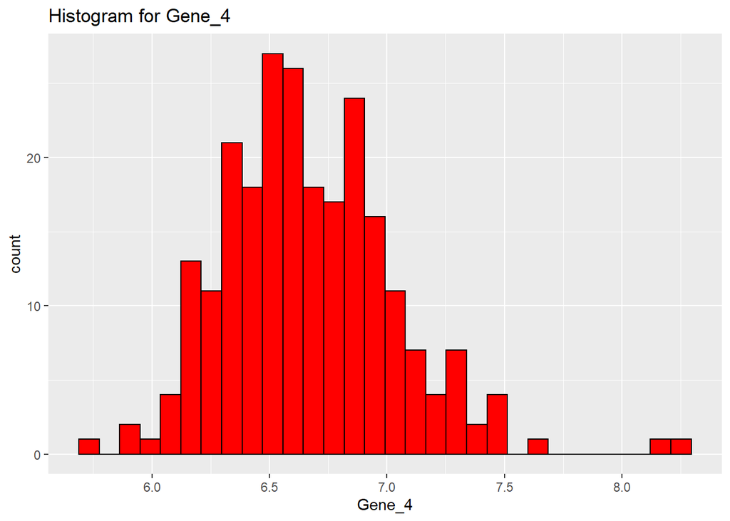

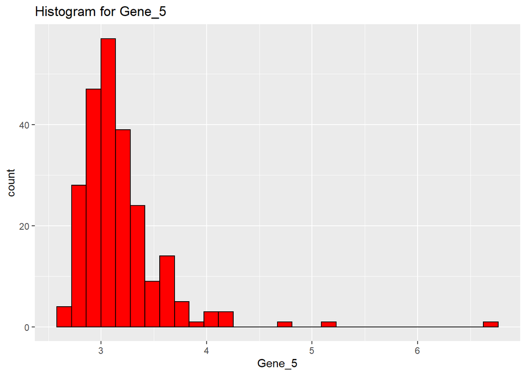

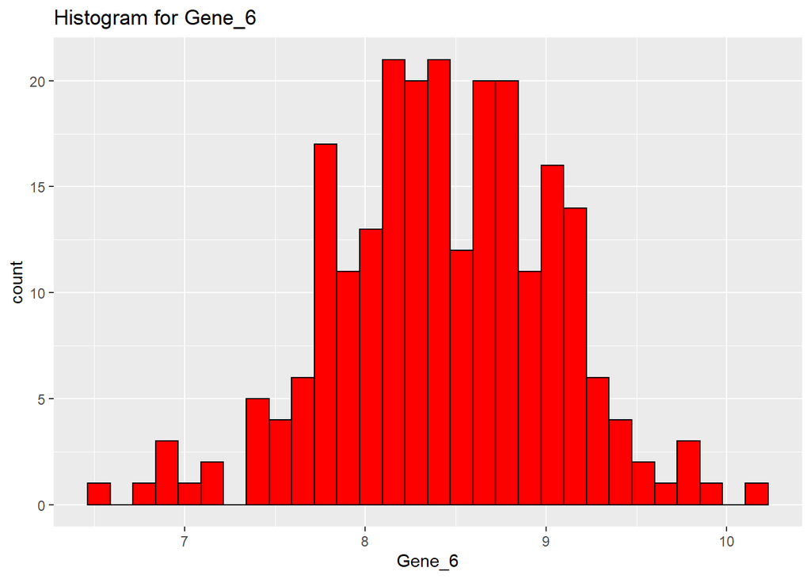

```r
gene_hist <- gene[, 2:7]
colnames(gene_hist) <- c(paste("Gene", 1:6, sep = "_"))

plots <- list()
for(i in names(gene_hist)){
    plots[[i]] <- ggplot(data = gene_hist, aes_string(x = i)) +
    geom_histogram(color = "black", fill = "red") +
    ggtitle(paste("Histogram for", i, sep = " "))
}

plots
```

It can also be plotted like so (so that it can all be in one graph rather than separately):

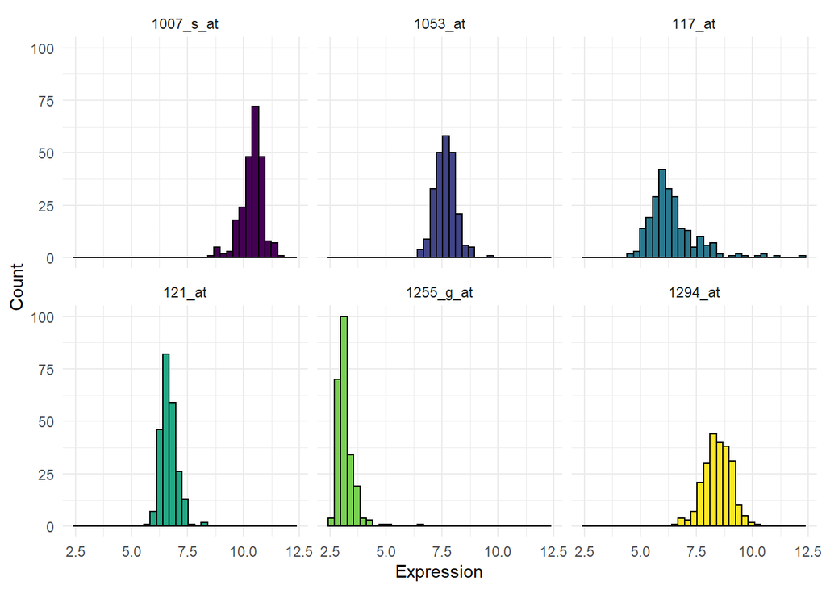

```r
gene[, 1:7] %>%
  pivot_longer(-sample, names_to = "gene") %>%
  ggplot(aes(x = value, fill = gene)) +
  geom_histogram(colour = "black", bins = 35) +
  theme_minimal() +
  facet_wrap(~gene) +
  labs(x = "Expression", y = "Count") +
  scale_fill_viridis_d(guide = "none")
```

- `Gene_1`: Also known as `1007_s_at`, is negatively skewewed, with outliers falling between 0 and 9.5. Most observation fall between 10 and 11, with the peak at about 10.5.
- `Gene_2`: Also known as `1053_at`, has most of the observations falling between 7 and 9. However, there is one outlier that is nearly at 10. The peak of the distribution is at about 7.75.
- `Gene_3`: Also known as `117_at`, is positively skewed, with outliers galling between 8.5 and 12. Most observations fall between 4 and 8. The peak of the distribution is at about 6.
- `Gene_4`: Also known as `121_at`, has most of the observations between 6 and 7.5. There are 2 outliers that are at about 8.5. The peak of the distribution is at about 6.5.
- `Gene_5`: Also known as `1255_g_at`, is severely positively skewed. Most of the observations fall between 0 and 4. However, there are 2 observations at about 5 and 1 observation at nearly 7. The peak of the distribution is at about 3.
- `Gene_6`: Also known as `1294_at`, has most observations between 7.5 and 9.5. There are some observations that are above below 7 and above 9.5.

**3: We now only have the gene expression data, but the labels are in the file `phenotypes.rds`. Load that file, `select()` the relevant columns for classification into normal and tumor tissue, and `join()` it with the gene expression data, based on the tissue identifier in the sample column. Give the resulting dataset a good name!**

```r
pheno <- read_rds(file = "phenotypes.rds")

gene_class <- pheno %>%
  mutate(disease = as_factor(disease)) %>%
  select(sample, disease) %>%
  right_join(gene)
```

Be careful when using `join()` functions because some will results in missing values, depending on which dataset is on the left or right.

- `inner_join()`: includes all rows in x and y.
- `left_join()`: includes all rows in x.
- `right_join()`: includes all rows in y.
- `full_join()`: includes all rows in x or y.

**4: Does this dataset suffer from class imbalance?**

```r
table(gene_class$disease)
```

```
##
## normal  tumor
##    116    121
```

```r
#or

prop.table(table(gene_class$disease))
```

```
##
##    normal     tumor
## 0.4894515 0.5105485
```

No, this dataset does not suffer from class imbalance. Normal has 116 observations and tumor has 121, making the difference between them only 5, which is good.

**5: Split the data into a training (80%) and a test set (20%). We will use the training set for model development in the next section.**

```r
set.seed(45)
train_idx <- sample(237, 190)
gene_train <- gene_class[train_idx,]
gene_test  <- gene_class[-train_idx,]
```

# Correlation filter & logistic regression

In this section, we will perform class prediction with this dataset using filtering and logistic regression. For the model development parts, use the training dataset.

**6: Use a correlation filter to find the IDs of the 10 genes that are most related to disease status.**

```r
# get disease status as an indicator (for the cor function)
y <- as.numeric(gene_train$disease == "tumor") #this will turn the values into T/F first and then into numeric (1s and 0s) - this is a quick way to do it without ifelse()

# get the gene expressions as a matrix (for the apply function)
X <- gene_train %>%
    select(-disease, -sample) %>%
    as.matrix()

# use the apply function to get a correlation of every column (margin = 2) with the disease status
cors <- apply(X, 2, cor, y = y)

# select the 10 most correlating genes (don't forget the abs() function!)
(cors_10 <- sort(abs(cors), decreasing = TRUE)[1:10])
```

```
## 209424_s_at   242138_at 209426_s_at   232575_at   209425_at 206858_s_at
##   0.7468092   0.7441597   0.7345152   0.7270552   0.7257923   0.7255545
##   207147_at 204934_s_at   236365_at   217111_at
##   0.7210385   0.7142122   0.7052019   0.7050075
```

**7: Perform logistic regression, predicting the outcome using the selected genes. Name the fitted object fit_lr.**

```r
lr_mod <- glm(formula = disease ~ `209424_s_at` + `242138_at` + `209426_s_at` + `232575_at` + `209425_at` +
  `206858_s_at` + `207147_at` + `204934_s_at` + `236365_at` + `217111_at`, family = "binomial", data = gene_train)

summary(lr_mod)
```

```
##
## Call:
## glm(formula = disease ~ `209424_s_at` + `242138_at` + `209426_s_at` +
##     `232575_at` + `209425_at` + `206858_s_at` + `207147_at` +
##     `204934_s_at` + `236365_at` + `217111_at`, family = "binomial",
##     data = gene_train)
##
## Deviance Residuals:
##      Min        1Q    Median        3Q       Max
## -1.41353  -0.22586   0.00133   0.03044   2.94022
##
## Coefficients:
##                Estimate Std. Error z value Pr(>|z|)
## (Intercept)   -24.28706    5.32947  -4.557 5.19e-06 ***
## `209424_s_at`   0.47378    0.74468   0.636   0.5246
## `242138_at`     0.56413    0.48396   1.166   0.2438
## `209426_s_at`  -0.08493    0.76242  -0.111   0.9113
## `232575_at`     0.45622    0.32990   1.383   0.1667
## `209425_at`     0.58400    1.07048   0.546   0.5854
## `206858_s_at`   0.82918    0.34501   2.403   0.0162 *
## `207147_at`     1.02348    0.58740   1.742   0.0814 .
## `204934_s_at`  -0.03303    0.48325  -0.068   0.9455
## `236365_at`    -0.15008    0.83584  -0.180   0.8575
## `217111_at`    -0.05181    0.83299  -0.062   0.9504
## ---
## Signif. codes:  0 '***' 0.001 '**' 0.01 '*' 0.05 '.' 0.1 ' ' 1
##
## (Dispersion parameter for binomial family taken to be 1)
##
##     Null deviance: 263.059  on 189  degrees of freedom
## Residual deviance:  59.631  on 179  degrees of freedom
## AIC: 81.631
##
## Number of Fisher Scoring iterations: 8
```

**8: Create a confusion matrix for the predictions of this model on the test set. What is the accuracy of this model?**

```r
pred_new_tab <- predict(object = lr_mod, newdata = gene_test, type = "response")
pred_new_tab <- ifelse(pred_new_tab > 0.5, "Yes", "No")

tab_log <- table(true = gene_test$disease, predicted = pred_new_tab)
tab_log
```

```
##         predicted
## true     No Yes
##   normal 22   3
##   tumor   2  20
```

```r
sum(diag(tab_log))/sum(tab_log)
```

```
## [1] 0.893617
```

The accuracy is 89%.

# Regularized regression

In this section, we will use the `glmnet` package to perform LASSO regression, which will automatically set certain coefficients to 0. The first step in performing LASSO regression is to prepare the data in the correct format. Read the help file of `glmnet()` to figure out what the x and y inputs should be.

**9: Prepare your data for input into glmnet. Create `x_train`, `y_train`, `x_test`, and `y_test`.**

```r
#train
x_train <- gene_train %>% select(-sample, -disease) %>% as.matrix()
y_train <- gene_train %>% pull(disease)

#test
x_test <- gene_test %>% select(-sample, -disease) %>% as.matrix()
y_test <- gene_test %>% pull(disease)
```

**10: Use the `glmnet` function to fit a LASSO regression. Use the `plot()` function on the fitted model and describe what you see.**

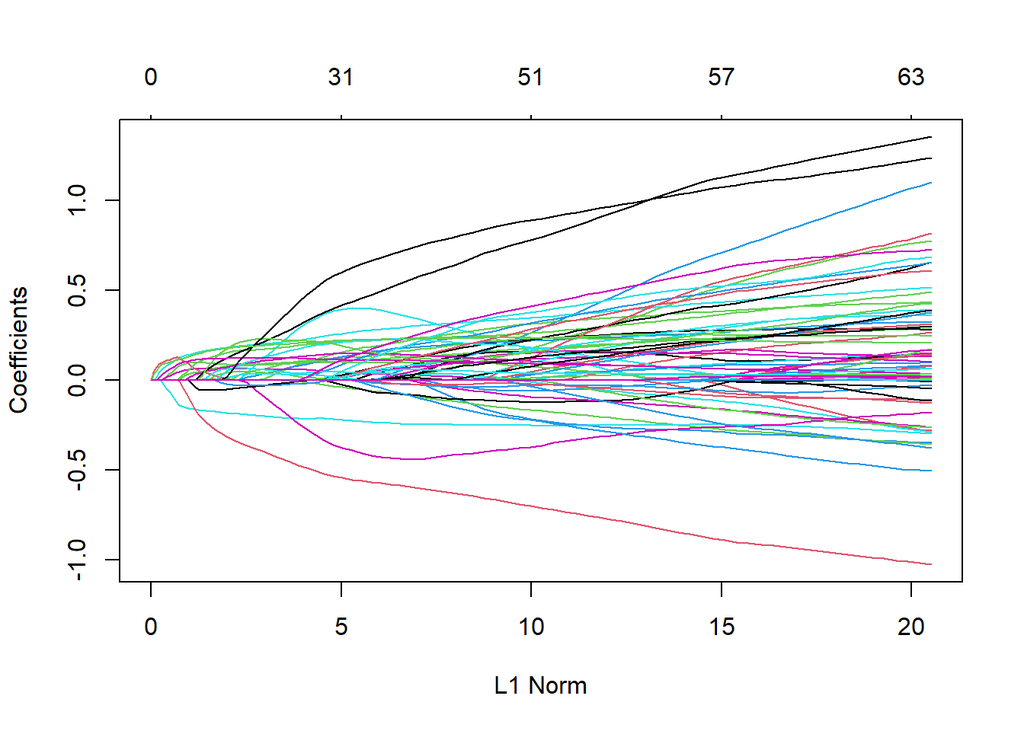

```r
mod1_glm <- glmnet(x = x_train, # X matrix without intercept
                   y = y_train, # Salary as response
                   family = "binomial", # Normally distributed errors
                   alpha = 1) # LASSO Penalty
plot(mod1_glm)
```

How to interpret this plot: Each line is a coefficient, with its value on the y-axis. On the x - axis we see the total budget for the parameters. As we decrease the budget (right-to-left), the coefficients shrink towards 0. Decreasing the budget further, some coefficients will become exactly 0, which is shown in the number of non-zero parameters (on top).

The next step is finding the right penalization parameter λ. In other words, we need to tune this hyperparameter. We want to select the hyperparameter which yields the best out-of-sample prediction performance. We could do this by further splitting the training dataset into a train and development subset, or with cross-validation. In this case, we will use the built-in cross-validation function of the glmnet package: `cv.glmnet`.

**11: Run `cv.glmnet` for your dataset. Run the `plot()` function on the resulting object. Explain in your own words what you see. NB: Do not forget to set `family = "binomial"` to ensure that you are running logistic regression.**

Lambda should should be tuned on the training data so that it is not exposed to the test data, making it biased. The `cv.glmnet()` function does run a LASSO regression with the best lambda., so you do not need to make another model using the best lambda value.

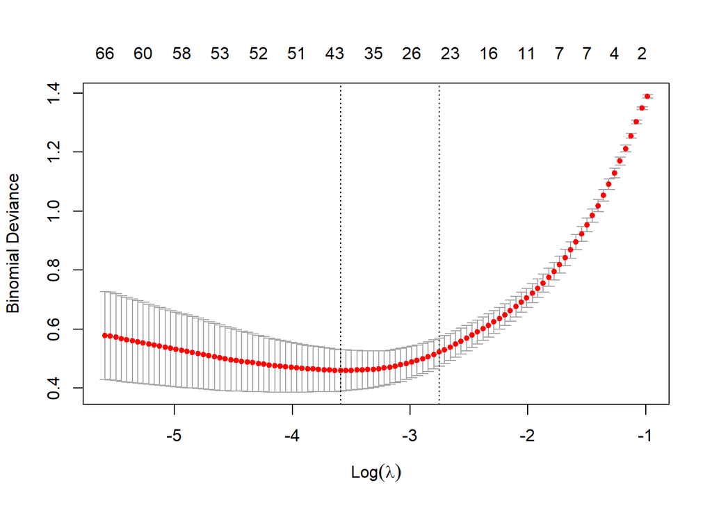

```r
mod2_glm <- cv.glmnet(x = x_train,
                      y = y_train,
                      nfolds = 10,
                      family = "binomial")
plot(mod2_glm)
```

We see a plot with on the x-axis the log of the penalty (complexity) and on the y axis the binomial deviance (lack of fit). On top, there is the number of nonzero parameters. The cross-validation procedure has computed for different levels of lambda the out-of-sample deviance.

If we go to the right, the cross-validation error increases, but also not by a lot in first instance. The dashed line on the right, indicates the largest possible lambda value (and thus the simplest model) within 1SE from the estimated MSE of the “best” model. The dashed line on the left indicates the optimal value for lambda. When we continue going to the right, the model becomes too simple and hence the bias increases quite substantially.

**12: Inspect the nonzero coefficients of the model with the lowest out-of-sample deviance. Hint: use the `coef()` function, and make sure to use the right value for the s argument to that function. Do you see overlap between the correlation filter selections and the LASSO results?**

```r
#saving the coefficients
coefs_1se <- coef(mod2_glm, s = "lambda.min")

#saving the coefficients with a non-zero index
nonzero_idx <- which(coefs_1se[,1] != 0)

#subsetting the coefficients so that it only displays indices which are nonzero
coefs_1se[nonzero_idx,]
```

```
##   (Intercept)  1552666_a_at    1553561_at    1558489_at    1559861_at
## -13.815760253   0.109047140   0.041621016   0.007357958   0.135971034
##    1561232_at    1561555_at  1566137_s_at  1570425_s_at   201877_s_at
##   0.092398285   0.321915500   0.143523318   0.240307568  -0.041703816
##     203393_at   204430_s_at     204735_at     205083_at     205202_at
##   0.081759546  -0.101113381  -0.010136251  -0.246611320  -0.432237537
##     206023_at     206364_at   206858_s_at     207147_at   209244_s_at
##   0.179125395   0.189693770   0.307651970   0.025149174  -0.092640259
##   209426_s_at   211214_s_at   211330_s_at   211333_s_at   213877_x_at
##   0.237303890   0.096199709  -0.022820180   0.063545546  -0.029311397
##   216258_s_at   216548_x_at     217170_at     218487_at     218931_at
##   0.212913674   0.032348352   0.070664896  -0.026417998   0.102875468
##     220541_at     223652_at   224460_s_at     227653_at     229703_at
##   0.135141208  -0.116867888   0.220905057   0.597606843   0.117741168
##     232575_at     233327_at     238239_at     238463_at     241110_at
##   0.105691542   0.149565741   0.764672092  -0.610048991   0.239376191
##     241235_at     241310_at     242138_at     243551_at
##   0.275540645   0.049418164   0.227762711   0.056388035
```

```r
# using this train-test split, the following genes are in both selections
intersect(names(cors_10), names(coefs_1se[nonzero_idx,]))
```

```
## [1] "242138_at"   "209426_s_at" "232575_at"   "206858_s_at" "207147_at"
```

There are some (5) that overlap, but it is not complete overlap.

**13: Use the `predict()` function on the fitted `cv.glmnet` object to predict disease status for the test set based on the optimized lambda value. Create a confusion matrix and compare this with the logistic regression model we made earlier in terms of accuracy.**

```r
#creating predictions using the test set
pred_glmnet <- predict(mod2_glm, newx = x_test, s = "lambda.min", type = "response")

#creating a confusion matrix
tab_pred <- table(observed = gene_test$disease, predicted = ifelse(pred_glmnet > 0.5, "tumor", "normal"))

#calculating the accuracy
sum(diag(tab_pred))/sum(tab_pred)
```

```
## [1] 0.9148936
```

Now, the accuracy is 91%. So, it is a slight improvement over the correlation filter that was used.